# Risk Factor Analysis

## Outcome Variable

**Outcome Variable:** haz

## Predictor Variables

**Intervention Variable:** parity

**Adjustment Set:**

unadjusted

## Stratifying Variables

The analysis was stratified on these variable(s):

- agecat
- studyid
- country

## Data Summary

| agecat | studyid | country | parity | n_cell | n |
| --- | --- | --- | --- | --- | --- |
| Birth | COHORTS | GUATEMALA | 1 | 112 | 852 |
| Birth | COHORTS | GUATEMALA | 2 | 137 | 852 |
| Birth | COHORTS | GUATEMALA | 3+ | 603 | 852 |
| Birth | COHORTS | INDIA | 1 | 696 | 4122 |
| Birth | COHORTS | INDIA | 2 | 1037 | 4122 |
| Birth | COHORTS | INDIA | 3+ | 2389 | 4122 |
| Birth | COHORTS | PHILIPPINES | 1 | 675 | 3050 |
| Birth | COHORTS | PHILIPPINES | 2 | 687 | 3050 |
| Birth | COHORTS | PHILIPPINES | 3+ | 1688 | 3050 |
| Birth | GMS-Nepal | NEPAL | 1 | 211 | 696 |
| Birth | GMS-Nepal | NEPAL | 2 | 180 | 696 |
| Birth | GMS-Nepal | NEPAL | 3+ | 305 | 696 |
| Birth | Keneba | GAMBIA | 1 | 156 | 1407 |
| Birth | Keneba | GAMBIA | 2 | 146 | 1407 |
| Birth | Keneba | GAMBIA | 3+ | 1105 | 1407 |
| Birth | PROVIDE | BANGLADESH | 1 | 206 | 539 |
| Birth | PROVIDE | BANGLADESH | 2 | 183 | 539 |
| Birth | PROVIDE | BANGLADESH | 3+ | 150 | 539 |
| Birth | SAS-CompFeed | INDIA | 1 | 361 | 1252 |
| Birth | SAS-CompFeed | INDIA | 2 | 289 | 1252 |
| Birth | SAS-CompFeed | INDIA | 3+ | 602 | 1252 |
| Birth | ZVITAMBO | ZIMBABWE | 1 | 5989 | 13874 |
| Birth | ZVITAMBO | ZIMBABWE | 2 | 4144 | 13874 |
| Birth | ZVITAMBO | ZIMBABWE | 3+ | 3741 | 13874 |
| 6 months | COHORTS | GUATEMALA | 1 | 132 | 961 |
| 6 months | COHORTS | GUATEMALA | 2 | 139 | 961 |
| 6 months | COHORTS | GUATEMALA | 3+ | 690 | 961 |
| 6 months | COHORTS | INDIA | 1 | 740 | 4291 |
| 6 months | COHORTS | INDIA | 2 | 1096 | 4291 |
| 6 months | COHORTS | INDIA | 3+ | 2455 | 4291 |
| 6 months | COHORTS | PHILIPPINES | 1 | 574 | 2708 |
| 6 months | COHORTS | PHILIPPINES | 2 | 606 | 2708 |
| 6 months | COHORTS | PHILIPPINES | 3+ | 1528 | 2708 |
| 6 months | GMS-Nepal | NEPAL | 1 | 153 | 564 |
| 6 months | GMS-Nepal | NEPAL | 2 | 149 | 564 |
| 6 months | GMS-Nepal | NEPAL | 3+ | 262 | 564 |
| 6 months | Keneba | GAMBIA | 1 | 194 | 1623 |
| 6 months | Keneba | GAMBIA | 2 | 164 | 1623 |
| 6 months | Keneba | GAMBIA | 3+ | 1265 | 1623 |
| 6 months | PROVIDE | BANGLADESH | 1 | 218 | 604 |
| 6 months | PROVIDE | BANGLADESH | 2 | 222 | 604 |
| 6 months | PROVIDE | BANGLADESH | 3+ | 164 | 604 |
| 6 months | SAS-CompFeed | INDIA | 1 | 392 | 1336 |
| 6 months | SAS-CompFeed | INDIA | 2 | 304 | 1336 |
| 6 months | SAS-CompFeed | INDIA | 3+ | 640 | 1336 |
| 6 months | SAS-FoodSuppl | INDIA | 1 | 7 | 380 |
| 6 months | SAS-FoodSuppl | INDIA | 2 | 72 | 380 |
| 6 months | SAS-FoodSuppl | INDIA | 3+ | 301 | 380 |
| 6 months | TanzaniaChild2 | TANZANIA, UNITED REPUBLIC OF | 1 | 680 | 1995 |
| 6 months | TanzaniaChild2 | TANZANIA, UNITED REPUBLIC OF | 2 | 657 | 1995 |
| 6 months | TanzaniaChild2 | TANZANIA, UNITED REPUBLIC OF | 3+ | 658 | 1995 |
| 6 months | ZVITAMBO | ZIMBABWE | 1 | 3466 | 8668 |
| 6 months | ZVITAMBO | ZIMBABWE | 2 | 2638 | 8668 |
| 6 months | ZVITAMBO | ZIMBABWE | 3+ | 2564 | 8668 |
| 24 months | COHORTS | GUATEMALA | 1 | 166 | 1064 |
| 24 months | COHORTS | GUATEMALA | 2 | 151 | 1064 |
| 24 months | COHORTS | GUATEMALA | 3+ | 747 | 1064 |
| 24 months | COHORTS | INDIA | 1 | 564 | 3380 |
| 24 months | COHORTS | INDIA | 2 | 848 | 3380 |
| 24 months | COHORTS | INDIA | 3+ | 1968 | 3380 |
| 24 months | COHORTS | PHILIPPINES | 1 | 524 | 2445 |
| 24 months | COHORTS | PHILIPPINES | 2 | 544 | 2445 |
| 24 months | COHORTS | PHILIPPINES | 3+ | 1377 | 2445 |
| 24 months | GMS-Nepal | NEPAL | 1 | 130 | 488 |
| 24 months | GMS-Nepal | NEPAL | 2 | 130 | 488 |
| 24 months | GMS-Nepal | NEPAL | 3+ | 228 | 488 |
| 24 months | Keneba | GAMBIA | 1 | 137 | 1376 |
| 24 months | Keneba | GAMBIA | 2 | 139 | 1376 |
| 24 months | Keneba | GAMBIA | 3+ | 1100 | 1376 |
| 24 months | PROVIDE | BANGLADESH | 1 | 211 | 578 |
| 24 months | PROVIDE | BANGLADESH | 2 | 213 | 578 |
| 24 months | PROVIDE | BANGLADESH | 3+ | 154 | 578 |
| 24 months | TanzaniaChild2 | TANZANIA, UNITED REPUBLIC OF | 1 | 1 | 6 |
| 24 months | TanzaniaChild2 | TANZANIA, UNITED REPUBLIC OF | 2 | 1 | 6 |
| 24 months | TanzaniaChild2 | TANZANIA, UNITED REPUBLIC OF | 3+ | 4 | 6 |
| 24 months | ZVITAMBO | ZIMBABWE | 1 | 640 | 1639 |
| 24 months | ZVITAMBO | ZIMBABWE | 2 | 507 | 1639 |
| 24 months | ZVITAMBO | ZIMBABWE | 3+ | 492 | 1639 |

The following strata were considered:

- agecat: 24 months, studyid: COHORTS, country: GUATEMALA
- agecat: 24 months, studyid: COHORTS, country: INDIA
- agecat: 24 months, studyid: COHORTS, country: PHILIPPINES
- agecat: 24 months, studyid: GMS-Nepal, country: NEPAL
- agecat: 24 months, studyid: Keneba, country: GAMBIA
- agecat: 24 months, studyid: PROVIDE, country: BANGLADESH
- agecat: 24 months, studyid: TanzaniaChild2, country: TANZANIA, UNITED REPUBLIC OF
- agecat: 24 months, studyid: ZVITAMBO, country: ZIMBABWE
- agecat: 6 months, studyid: COHORTS, country: GUATEMALA
- agecat: 6 months, studyid: COHORTS, country: INDIA
- agecat: 6 months, studyid: COHORTS, country: PHILIPPINES
- agecat: 6 months, studyid: GMS-Nepal, country: NEPAL
- agecat: 6 months, studyid: Keneba, country: GAMBIA
- agecat: 6 months, studyid: PROVIDE, country: BANGLADESH
- agecat: 6 months, studyid: SAS-CompFeed, country: INDIA
- agecat: 6 months, studyid: SAS-FoodSuppl, country: INDIA
- agecat: 6 months, studyid: TanzaniaChild2, country: TANZANIA, UNITED REPUBLIC OF
- agecat: 6 months, studyid: ZVITAMBO, country: ZIMBABWE
- agecat: Birth, studyid: COHORTS, country: GUATEMALA
- agecat: Birth, studyid: COHORTS, country: INDIA
- agecat: Birth, studyid: COHORTS, country: PHILIPPINES
- agecat: Birth, studyid: GMS-Nepal, country: NEPAL
- agecat: Birth, studyid: Keneba, country: GAMBIA
- agecat: Birth, studyid: PROVIDE, country: BANGLADESH
- agecat: Birth, studyid: SAS-CompFeed, country: INDIA
- agecat: Birth, studyid: ZVITAMBO, country: ZIMBABWE

### Dropped Strata

Some strata were dropped due to rare outcomes:

- agecat: 24 months, studyid: TanzaniaChild2, country: TANZANIA, UNITED REPUBLIC OF

## Methods Detail

We’re interested in the causal parameters $E[Y_a]$ for all values of $a \in \mathcal{A}$. These parameters represent the mean outcome if, possibly contrary to fact, we intervened to set all units to have $A=a$. Under the randomization and positivity assumptions, these are identified by the statistical parameters $\psi_a=E_W[E_{Y|A,W}(Y|A=a,W)]$. In addition, we’re interested in the mean of $Y$, $E[Y]$ under no intervention (the observed mean). We will estimate these parameters by using SuperLearner to fit the relevant likelihood factors – $E_{Y|A,W}(Y|A=a,W)$ and $p(A=a|W)$, and then updating our likelihood fit using a joint TMLE.

For unadjusted analyses ($W=\{\}$), initial likelihoods were estimated using Lrnr_glm to estimate the simple $E(Y|A)$ and Lrnr_mean to estimate $p(A)$. For adjusted analyses, a small library containing Lrnr_glmnet, Lrnr_xgboost, and Lrnr_mean was used.

Having estimated these parameters, we will then use the delta method to estimate relative risks and attributable risks relative to a prespecified baseline level of $A$.

# Results Detail

## Results Plots

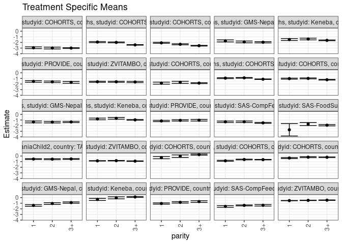

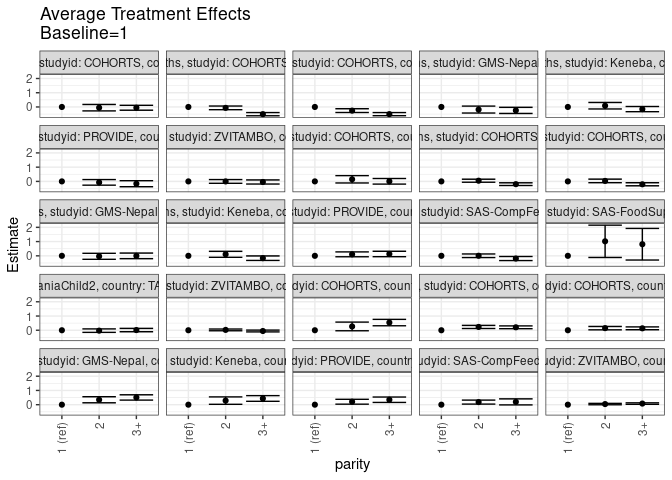

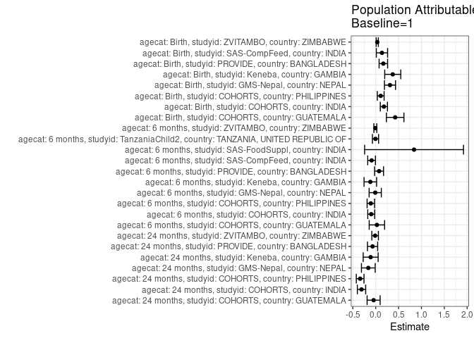

## Results Table

### Parameter: TSM

| agecat | studyid | country | intervention_level | baseline_level | estimate | ci_lower | ci_upper |
| --- | --- | --- | --- | --- | --- | --- | --- |
| Birth | COHORTS | GUATEMALA | 1 | NA | -0.2955357 | -0.4961176 | -0.0949538 |
| Birth | COHORTS | GUATEMALA | 2 | NA | -0.0281752 | -0.2562105 | 0.1998601 |
| Birth | COHORTS | GUATEMALA | 3+ | NA | 0.2445937 | 0.1463298 | 0.3428576 |
| Birth | COHORTS | INDIA | 1 | NA | -0.8560489 | -0.9418893 | -0.7702084 |
| Birth | COHORTS | INDIA | 2 | NA | -0.6238284 | -0.6910831 | -0.5565736 |
| Birth | COHORTS | INDIA | 3+ | NA | -0.6484763 | -0.6951610 | -0.6017917 |
| Birth | COHORTS | PHILIPPINES | 1 | NA | -0.3580296 | -0.4429059 | -0.2731534 |
| Birth | COHORTS | PHILIPPINES | 2 | NA | -0.2091994 | -0.2907964 | -0.1276025 |
| Birth | COHORTS | PHILIPPINES | 3+ | NA | -0.2216884 | -0.2736422 | -0.1697346 |
| Birth | GMS-Nepal | NEPAL | 1 | NA | -1.3972038 | -1.5420135 | -1.2523941 |
| Birth | GMS-Nepal | NEPAL | 2 | NA | -1.0515000 | -1.2077080 | -0.8952920 |
| Birth | GMS-Nepal | NEPAL | 3+ | NA | -0.8891475 | -1.0052035 | -0.7730915 |
| Birth | Keneba | GAMBIA | 1 | NA | -0.3241667 | -0.5080084 | -0.1403249 |
| Birth | Keneba | GAMBIA | 2 | NA | -0.0376027 | -0.2207645 | 0.1455591 |
| Birth | Keneba | GAMBIA | 3+ | NA | 0.1122715 | 0.0358040 | 0.1887390 |
| Birth | PROVIDE | BANGLADESH | 1 | NA | -1.0523786 | -1.1655486 | -0.9392087 |
| Birth | PROVIDE | BANGLADESH | 2 | NA | -0.8445355 | -0.9715480 | -0.7175231 |
| Birth | PROVIDE | BANGLADESH | 3+ | NA | -0.7048667 | -0.8553762 | -0.5543571 |
| Birth | SAS-CompFeed | INDIA | 1 | NA | -1.5680886 | -1.7156591 | -1.4205181 |
| Birth | SAS-CompFeed | INDIA | 2 | NA | -1.3870934 | -1.4733440 | -1.3008428 |
| Birth | SAS-CompFeed | INDIA | 3+ | NA | -1.3707475 | -1.5061744 | -1.2353206 |
| Birth | ZVITAMBO | ZIMBABWE | 1 | NA | -0.5342227 | -0.5656388 | -0.5028067 |
| Birth | ZVITAMBO | ZIMBABWE | 2 | NA | -0.4913345 | -0.5273942 | -0.4552747 |
| Birth | ZVITAMBO | ZIMBABWE | 3+ | NA | -0.4560064 | -0.4969520 | -0.4150609 |
| 6 months | COHORTS | GUATEMALA | 1 | NA | -1.8418939 | -2.0228076 | -1.6609802 |
| 6 months | COHORTS | GUATEMALA | 2 | NA | -1.6951799 | -1.8774684 | -1.5128913 |
| 6 months | COHORTS | GUATEMALA | 3+ | NA | -1.8350145 | -1.9150976 | -1.7549314 |
| 6 months | COHORTS | INDIA | 1 | NA | -0.9470541 | -1.0297223 | -0.8643858 |
| 6 months | COHORTS | INDIA | 2 | NA | -0.8993339 | -0.9666636 | -0.8320043 |
| 6 months | COHORTS | INDIA | 3+ | NA | -1.1404318 | -1.1872366 | -1.0936270 |
| 6 months | COHORTS | PHILIPPINES | 1 | NA | -1.0339895 | -1.1258821 | -0.9420970 |
| 6 months | COHORTS | PHILIPPINES | 2 | NA | -1.0007261 | -1.0872914 | -0.9141607 |
| 6 months | COHORTS | PHILIPPINES | 3+ | NA | -1.2360733 | -1.2917219 | -1.1804247 |
| 6 months | GMS-Nepal | NEPAL | 1 | NA | -1.3403922 | -1.4995103 | -1.1812741 |
| 6 months | GMS-Nepal | NEPAL | 2 | NA | -1.3737919 | -1.5137977 | -1.2337862 |
| 6 months | GMS-Nepal | NEPAL | 3+ | NA | -1.3438868 | -1.4595398 | -1.2282337 |
| 6 months | Keneba | GAMBIA | 1 | NA | -0.8062506 | -0.9513604 | -0.6611408 |
| 6 months | Keneba | GAMBIA | 2 | NA | -0.6999654 | -0.8511450 | -0.5487859 |
| 6 months | Keneba | GAMBIA | 3+ | NA | -0.9710240 | -1.0317692 | -0.9102787 |
| 6 months | PROVIDE | BANGLADESH | 1 | NA | -1.1655122 | -1.2848545 | -1.0461699 |
| 6 months | PROVIDE | BANGLADESH | 2 | NA | -1.0600225 | -1.1828853 | -0.9371598 |
| 6 months | PROVIDE | BANGLADESH | 3+ | NA | -1.0364329 | -1.1848722 | -0.8879937 |
| 6 months | SAS-CompFeed | INDIA | 1 | NA | -1.3118367 | -1.4373576 | -1.1863158 |
| 6 months | SAS-CompFeed | INDIA | 2 | NA | -1.3070888 | -1.4410886 | -1.1730890 |
| 6 months | SAS-CompFeed | INDIA | 3+ | NA | -1.5020078 | -1.5877472 | -1.4162684 |
| 6 months | SAS-FoodSuppl | INDIA | 1 | NA | -2.7371429 | -3.8398050 | -1.6344807 |
| 6 months | SAS-FoodSuppl | INDIA | 2 | NA | -1.7179167 | -1.9871634 | -1.4486700 |
| 6 months | SAS-FoodSuppl | INDIA | 3+ | NA | -1.9224252 | -2.0438733 | -1.8009772 |
| 6 months | TanzaniaChild2 | TANZANIA, UNITED REPUBLIC OF | 1 | NA | -0.5386838 | -0.6201834 | -0.4571842 |
| 6 months | TanzaniaChild2 | TANZANIA, UNITED REPUBLIC OF | 2 | NA | -0.5657902 | -0.6562982 | -0.4752822 |
| 6 months | TanzaniaChild2 | TANZANIA, UNITED REPUBLIC OF | 3+ | NA | -0.5255471 | -0.6099074 | -0.4411868 |
| 6 months | ZVITAMBO | ZIMBABWE | 1 | NA | -0.8601125 | -0.9007812 | -0.8194438 |
| 6 months | ZVITAMBO | ZIMBABWE | 2 | NA | -0.8343442 | -0.8798633 | -0.7888251 |
| 6 months | ZVITAMBO | ZIMBABWE | 3+ | NA | -0.9132508 | -0.9606736 | -0.8658280 |
| 24 months | COHORTS | GUATEMALA | 1 | NA | -2.9450602 | -3.0984447 | -2.7916758 |
| 24 months | COHORTS | GUATEMALA | 2 | NA | -2.9956954 | -3.1608270 | -2.8305638 |
| 24 months | COHORTS | GUATEMALA | 3+ | NA | -2.9996787 | -3.0777348 | -2.9216226 |
| 24 months | COHORTS | INDIA | 1 | NA | -1.9295922 | -2.0293090 | -1.8298754 |
| 24 months | COHORTS | INDIA | 2 | NA | -1.9930660 | -2.0729384 | -1.9131936 |
| 24 months | COHORTS | INDIA | 3+ | NA | -2.4349441 | -2.4879405 | -2.3819477 |
| 24 months | COHORTS | PHILIPPINES | 1 | NA | -2.0738168 | -2.1676894 | -1.9799442 |
| 24 months | COHORTS | PHILIPPINES | 2 | NA | -2.3297059 | -2.4223024 | -2.2371093 |
| 24 months | COHORTS | PHILIPPINES | 3+ | NA | -2.5769572 | -2.6365887 | -2.5173256 |
| 24 months | GMS-Nepal | NEPAL | 1 | NA | -1.7259231 | -1.9064905 | -1.5453557 |
| 24 months | GMS-Nepal | NEPAL | 2 | NA | -1.9082692 | -2.0718832 | -1.7446553 |
| 24 months | GMS-Nepal | NEPAL | 3+ | NA | -1.9676096 | -2.0849819 | -1.8502374 |
| 24 months | Keneba | GAMBIA | 1 | NA | -1.4779100 | -1.6496081 | -1.3062118 |
| 24 months | Keneba | GAMBIA | 2 | NA | -1.3899412 | -1.5409282 | -1.2389543 |
| 24 months | Keneba | GAMBIA | 3+ | NA | -1.6271244 | -1.6909196 | -1.5633292 |
| 24 months | PROVIDE | BANGLADESH | 1 | NA | -1.5336730 | -1.6770716 | -1.3902744 |
| 24 months | PROVIDE | BANGLADESH | 2 | NA | -1.6026761 | -1.7373193 | -1.4680328 |
| 24 months | PROVIDE | BANGLADESH | 3+ | NA | -1.6962662 | -1.8516014 | -1.5409311 |
| 24 months | ZVITAMBO | ZIMBABWE | 1 | NA | -1.5927031 | -1.6862811 | -1.4991252 |
| 24 months | ZVITAMBO | ZIMBABWE | 2 | NA | -1.5953649 | -1.6888244 | -1.5019054 |
| 24 months | ZVITAMBO | ZIMBABWE | 3+ | NA | -1.6341362 | -1.7435617 | -1.5247107 |

### Parameter: E(Y)

| agecat | studyid | country | intervention_level | baseline_level | estimate | ci_lower | ci_upper |
| --- | --- | --- | --- | --- | --- | --- | --- |
| Birth | COHORTS | GUATEMALA | NA | NA | 0.1297300 | 0.0458017 | 0.2136584 |
| Birth | COHORTS | INDIA | NA | NA | -0.6773241 | -0.7124609 | -0.6421873 |
| Birth | COHORTS | PHILIPPINES | NA | NA | -0.2490492 | -0.2880580 | -0.2100404 |
| Birth | GMS-Nepal | NEPAL | NA | NA | -1.0851580 | -1.1651811 | -1.0051350 |
| Birth | Keneba | GAMBIA | NA | NA | 0.0483298 | -0.0182746 | 0.1149342 |
| Birth | PROVIDE | BANGLADESH | NA | NA | -0.8851020 | -0.9601332 | -0.8100709 |
| Birth | SAS-CompFeed | INDIA | NA | NA | -1.4314217 | -1.5099245 | -1.3529189 |
| Birth | ZVITAMBO | ZIMBABWE | NA | NA | -0.5003222 | -0.5208673 | -0.4797770 |
| 6 months | COHORTS | GUATEMALA | NA | NA | -1.8157336 | -1.8837688 | -1.7476985 |
| 6 months | COHORTS | INDIA | NA | NA | -1.0455022 | -1.0805318 | -1.0104727 |
| 6 months | COHORTS | PHILIPPINES | NA | NA | -1.1405724 | -1.1824954 | -1.0986493 |
| 6 months | GMS-Nepal | NEPAL | NA | NA | -1.3508392 | -1.4290633 | -1.2726152 |
| 6 months | Keneba | GAMBIA | NA | NA | -0.9239386 | -0.9768148 | -0.8710623 |
| 6 months | PROVIDE | BANGLADESH | NA | NA | -1.0916915 | -1.1661176 | -1.0172654 |
| 6 months | SAS-CompFeed | INDIA | NA | NA | -1.4018563 | -1.4810585 | -1.3226541 |
| 6 months | SAS-FoodSuppl | INDIA | NA | NA | -1.8986842 | -2.0118892 | -1.7854792 |
| 6 months | TanzaniaChild2 | TANZANIA, UNITED REPUBLIC OF | NA | NA | -0.5432778 | -0.5926218 | -0.4939338 |
| 6 months | ZVITAMBO | ZIMBABWE | NA | NA | -0.8679886 | -0.8935535 | -0.8424236 |
| 24 months | COHORTS | GUATEMALA | NA | NA | -2.9905921 | -3.0548289 | -2.9263553 |
| 24 months | COHORTS | INDIA | NA | NA | -2.2397574 | -2.2808841 | -2.1986307 |
| 24 months | COHORTS | PHILIPPINES | NA | NA | -2.4141145 | -2.4590818 | -2.3691473 |
| 24 months | GMS-Nepal | NEPAL | NA | NA | -1.8874180 | -1.9728588 | -1.8019773 |
| 24 months | Keneba | GAMBIA | NA | NA | -1.5883084 | -1.6443765 | -1.5322402 |
| 24 months | PROVIDE | BANGLADESH | NA | NA | -1.6024221 | -1.6857420 | -1.5191023 |
| 24 months | ZVITAMBO | ZIMBABWE | NA | NA | -1.6059640 | -1.6629797 | -1.5489484 |

### Parameter: ATE

| agecat | studyid | country | intervention_level | baseline_level | estimate | ci_lower | ci_upper |
| --- | --- | --- | --- | --- | --- | --- | --- |
| Birth | COHORTS | GUATEMALA | 1 | 1 | 0.0000000 | 0.0000000 | 0.0000000 |
| Birth | COHORTS | GUATEMALA | 2 | 1 | 0.2673605 | -0.0363386 | 0.5710597 |
| Birth | COHORTS | GUATEMALA | 3+ | 1 | 0.5401294 | 0.3167712 | 0.7634876 |
| Birth | COHORTS | INDIA | 1 | 1 | 0.0000000 | 0.0000000 | 0.0000000 |
| Birth | COHORTS | INDIA | 2 | 1 | 0.2322205 | 0.1231711 | 0.3412699 |
| Birth | COHORTS | INDIA | 3+ | 1 | 0.2075725 | 0.1098585 | 0.3052865 |
| Birth | COHORTS | PHILIPPINES | 1 | 1 | 0.0000000 | 0.0000000 | 0.0000000 |
| Birth | COHORTS | PHILIPPINES | 2 | 1 | 0.1488302 | 0.0310930 | 0.2665674 |
| Birth | COHORTS | PHILIPPINES | 3+ | 1 | 0.1363412 | 0.0368266 | 0.2358559 |
| Birth | GMS-Nepal | NEPAL | 1 | 1 | 0.0000000 | 0.0000000 | 0.0000000 |
| Birth | GMS-Nepal | NEPAL | 2 | 1 | 0.3457038 | 0.1326996 | 0.5587080 |
| Birth | GMS-Nepal | NEPAL | 3+ | 1 | 0.5080563 | 0.3224792 | 0.6936333 |
| Birth | Keneba | GAMBIA | 1 | 1 | 0.0000000 | 0.0000000 | 0.0000000 |
| Birth | Keneba | GAMBIA | 2 | 1 | 0.2865639 | 0.0270528 | 0.5460751 |
| Birth | Keneba | GAMBIA | 3+ | 1 | 0.4364382 | 0.2373275 | 0.6355488 |
| Birth | PROVIDE | BANGLADESH | 1 | 1 | 0.0000000 | 0.0000000 | 0.0000000 |
| Birth | PROVIDE | BANGLADESH | 2 | 1 | 0.2078431 | 0.0377267 | 0.3779596 |
| Birth | PROVIDE | BANGLADESH | 3+ | 1 | 0.3475120 | 0.1592022 | 0.5358217 |
| Birth | SAS-CompFeed | INDIA | 1 | 1 | 0.0000000 | 0.0000000 | 0.0000000 |
| Birth | SAS-CompFeed | INDIA | 2 | 1 | 0.1809952 | 0.0408312 | 0.3211592 |
| Birth | SAS-CompFeed | INDIA | 3+ | 1 | 0.1973411 | -0.0145363 | 0.4092186 |
| Birth | ZVITAMBO | ZIMBABWE | 1 | 1 | 0.0000000 | 0.0000000 | 0.0000000 |
| Birth | ZVITAMBO | ZIMBABWE | 2 | 1 | 0.0428883 | -0.0049372 | 0.0907137 |
| Birth | ZVITAMBO | ZIMBABWE | 3+ | 1 | 0.0782163 | 0.0266072 | 0.1298255 |
| 6 months | COHORTS | GUATEMALA | 1 | 1 | 0.0000000 | 0.0000000 | 0.0000000 |
| 6 months | COHORTS | GUATEMALA | 2 | 1 | 0.1467141 | -0.1101105 | 0.4035387 |
| 6 months | COHORTS | GUATEMALA | 3+ | 1 | 0.0068794 | -0.1909666 | 0.2047255 |
| 6 months | COHORTS | INDIA | 1 | 1 | 0.0000000 | 0.0000000 | 0.0000000 |
| 6 months | COHORTS | INDIA | 2 | 1 | 0.0477201 | -0.0588975 | 0.1543378 |
| 6 months | COHORTS | INDIA | 3+ | 1 | -0.1933777 | -0.2883763 | -0.0983791 |
| 6 months | COHORTS | PHILIPPINES | 1 | 1 | 0.0000000 | 0.0000000 | 0.0000000 |
| 6 months | COHORTS | PHILIPPINES | 2 | 1 | 0.0332635 | -0.0929815 | 0.1595085 |
| 6 months | COHORTS | PHILIPPINES | 3+ | 1 | -0.2020838 | -0.3095128 | -0.0946547 |
| 6 months | GMS-Nepal | NEPAL | 1 | 1 | 0.0000000 | 0.0000000 | 0.0000000 |
| 6 months | GMS-Nepal | NEPAL | 2 | 1 | -0.0333998 | -0.2453436 | 0.1785440 |
| 6 months | GMS-Nepal | NEPAL | 3+ | 1 | -0.0034946 | -0.2002030 | 0.1932138 |
| 6 months | Keneba | GAMBIA | 1 | 1 | 0.0000000 | 0.0000000 | 0.0000000 |
| 6 months | Keneba | GAMBIA | 2 | 1 | 0.1062851 | -0.1032670 | 0.3158373 |
| 6 months | Keneba | GAMBIA | 3+ | 1 | -0.1647734 | -0.3220847 | -0.0074621 |
| 6 months | PROVIDE | BANGLADESH | 1 | 1 | 0.0000000 | 0.0000000 | 0.0000000 |
| 6 months | PROVIDE | BANGLADESH | 2 | 1 | 0.1054897 | -0.0657932 | 0.2767726 |
| 6 months | PROVIDE | BANGLADESH | 3+ | 1 | 0.1290793 | -0.0613854 | 0.3195440 |
| 6 months | SAS-CompFeed | INDIA | 1 | 1 | 0.0000000 | 0.0000000 | 0.0000000 |
| 6 months | SAS-CompFeed | INDIA | 2 | 1 | 0.0047479 | -0.1210126 | 0.1305084 |
| 6 months | SAS-CompFeed | INDIA | 3+ | 1 | -0.1901711 | -0.3323896 | -0.0479526 |
| 6 months | SAS-FoodSuppl | INDIA | 1 | 1 | 0.0000000 | 0.0000000 | 0.0000000 |
| 6 months | SAS-FoodSuppl | INDIA | 2 | 1 | 1.0192262 | -0.1158322 | 2.1542846 |
| 6 months | SAS-FoodSuppl | INDIA | 3+ | 1 | 0.8147176 | -0.2946126 | 1.9240478 |
| 6 months | TanzaniaChild2 | TANZANIA, UNITED REPUBLIC OF | 1 | 1 | 0.0000000 | 0.0000000 | 0.0000000 |
| 6 months | TanzaniaChild2 | TANZANIA, UNITED REPUBLIC OF | 2 | 1 | -0.0271064 | -0.1489009 | 0.0946881 |
| 6 months | TanzaniaChild2 | TANZANIA, UNITED REPUBLIC OF | 3+ | 1 | 0.0131367 | -0.1041614 | 0.1304348 |
| 6 months | ZVITAMBO | ZIMBABWE | 1 | 1 | 0.0000000 | 0.0000000 | 0.0000000 |
| 6 months | ZVITAMBO | ZIMBABWE | 2 | 1 | 0.0257683 | -0.0352721 | 0.0868087 |
| 6 months | ZVITAMBO | ZIMBABWE | 3+ | 1 | -0.0531383 | -0.1156112 | 0.0093346 |
| 24 months | COHORTS | GUATEMALA | 1 | 1 | 0.0000000 | 0.0000000 | 0.0000000 |
| 24 months | COHORTS | GUATEMALA | 2 | 1 | -0.0506351 | -0.2760131 | 0.1747429 |
| 24 months | COHORTS | GUATEMALA | 3+ | 1 | -0.0546185 | -0.2267218 | 0.1174848 |
| 24 months | COHORTS | INDIA | 1 | 1 | 0.0000000 | 0.0000000 | 0.0000000 |
| 24 months | COHORTS | INDIA | 2 | 1 | -0.0634738 | -0.1912355 | 0.0642878 |
| 24 months | COHORTS | INDIA | 3+ | 1 | -0.5053519 | -0.6182770 | -0.3924269 |
| 24 months | COHORTS | PHILIPPINES | 1 | 1 | 0.0000000 | 0.0000000 | 0.0000000 |
| 24 months | COHORTS | PHILIPPINES | 2 | 1 | -0.2558891 | -0.3877458 | -0.1240324 |
| 24 months | COHORTS | PHILIPPINES | 3+ | 1 | -0.5031404 | -0.6143518 | -0.3919289 |
| 24 months | GMS-Nepal | NEPAL | 1 | 1 | 0.0000000 | 0.0000000 | 0.0000000 |
| 24 months | GMS-Nepal | NEPAL | 2 | 1 | -0.1823462 | -0.4260142 | 0.0613219 |
| 24 months | GMS-Nepal | NEPAL | 3+ | 1 | -0.2416866 | -0.4570487 | -0.0263245 |
| 24 months | Keneba | GAMBIA | 1 | 1 | 0.0000000 | 0.0000000 | 0.0000000 |
| 24 months | Keneba | GAMBIA | 2 | 1 | 0.0879687 | -0.1406736 | 0.3166111 |
| 24 months | Keneba | GAMBIA | 3+ | 1 | -0.1492144 | -0.3323813 | 0.0339524 |
| 24 months | PROVIDE | BANGLADESH | 1 | 1 | 0.0000000 | 0.0000000 | 0.0000000 |
| 24 months | PROVIDE | BANGLADESH | 2 | 1 | -0.0690031 | -0.2657058 | 0.1276997 |
| 24 months | PROVIDE | BANGLADESH | 3+ | 1 | -0.1625932 | -0.3739985 | 0.0488120 |
| 24 months | ZVITAMBO | ZIMBABWE | 1 | 1 | 0.0000000 | 0.0000000 | 0.0000000 |
| 24 months | ZVITAMBO | ZIMBABWE | 2 | 1 | -0.0026618 | -0.1349172 | 0.1295937 |
| 24 months | ZVITAMBO | ZIMBABWE | 3+ | 1 | -0.0414331 | -0.1854149 | 0.1025488 |

### Parameter: PAR

| agecat | studyid | country | intervention_level | baseline_level | estimate | ci_lower | ci_upper |
| --- | --- | --- | --- | --- | --- | --- | --- |
| Birth | COHORTS | GUATEMALA | 1 | NA | 0.4252658 | 0.2336950 | 0.6168365 |
| Birth | COHORTS | INDIA | 1 | NA | 0.1787247 | 0.1005275 | 0.2569219 |
| Birth | COHORTS | PHILIPPINES | 1 | NA | 0.1089804 | 0.0345693 | 0.1833916 |
| Birth | GMS-Nepal | NEPAL | 1 | NA | 0.3120457 | 0.1909712 | 0.4331203 |
| Birth | Keneba | GAMBIA | 1 | NA | 0.3724964 | 0.1971701 | 0.5478228 |
| Birth | PROVIDE | BANGLADESH | 1 | NA | 0.1672766 | 0.0742853 | 0.2602679 |
| Birth | SAS-CompFeed | INDIA | 1 | NA | 0.1366669 | 0.0131557 | 0.2601781 |
| Birth | ZVITAMBO | ZIMBABWE | 1 | NA | 0.0339006 | 0.0103001 | 0.0575010 |
| 6 months | COHORTS | GUATEMALA | 1 | NA | 0.0261603 | -0.1422654 | 0.1945861 |
| 6 months | COHORTS | INDIA | 1 | NA | -0.0984482 | -0.1739730 | -0.0229234 |
| 6 months | COHORTS | PHILIPPINES | 1 | NA | -0.1065828 | -0.1879586 | -0.0252070 |
| 6 months | GMS-Nepal | NEPAL | 1 | NA | -0.0104471 | -0.1434918 | 0.1225976 |
| 6 months | Keneba | GAMBIA | 1 | NA | -0.1176880 | -0.2548697 | 0.0194938 |
| 6 months | PROVIDE | BANGLADESH | 1 | NA | 0.0738207 | -0.0236511 | 0.1712926 |
| 6 months | SAS-CompFeed | INDIA | 1 | NA | -0.0900196 | -0.1744402 | -0.0055989 |
| 6 months | SAS-FoodSuppl | INDIA | 1 | NA | 0.8384586 | -0.2422291 | 1.9191464 |
| 6 months | TanzaniaChild2 | TANZANIA, UNITED REPUBLIC OF | 1 | NA | -0.0045940 | -0.0720403 | 0.0628524 |
| 6 months | ZVITAMBO | ZIMBABWE | 1 | NA | -0.0078761 | -0.0392578 | 0.0235057 |
| 24 months | COHORTS | GUATEMALA | 1 | NA | -0.0455319 | -0.1880524 | 0.0969886 |
| 24 months | COHORTS | INDIA | 1 | NA | -0.3101652 | -0.4013598 | -0.2189706 |
| 24 months | COHORTS | PHILIPPINES | 1 | NA | -0.3402977 | -0.4243037 | -0.2562917 |
| 24 months | GMS-Nepal | NEPAL | 1 | NA | -0.1614950 | -0.3116063 | -0.0113836 |
| 24 months | Keneba | GAMBIA | 1 | NA | -0.1103984 | -0.2739635 | 0.0531667 |
| 24 months | PROVIDE | BANGLADESH | 1 | NA | -0.0687492 | -0.1805173 | 0.0430190 |
| 24 months | ZVITAMBO | ZIMBABWE | 1 | NA | -0.0132609 | -0.0851556 | 0.0586338 |